# HW4b_2020

# Practical exercises

In the practical part of the assignment you will use RNNs to predict the amount of water flowing in a stream or river, the so-called *streamflow*, from meteorological data.

## The data

The data that you will be using for the training comes from a scientific dataset named *Catchment Attributes and Meteorology for Large-sample Studies* (CAMELS). It is described in detail in the following paper:

A. Newman; K. Sampson; M. P. Clark; A. Bock; R. J. Viger; D. Blodgett, 2014. A large-sample watershed-scale hydrometeorological dataset for the contiguous USA. Boulder, CO: UCAR/NCAR. https://dx.doi.org/10.5065/D6MW2F4D

The dataset contains time series of streamflow combined with the most important *meteorological forcings* for the given river or stream. The forcing values describe the most important meteorological processes that determine the streamflow. The princpial forcing is of course precipitation, i.e. rain and snow, but also the temperature and strength of solar can indirectly influence the streamflow. These forcings have been aggregated over the drainage basin, which is the area upstream of the gauge measuring the streamflow in which precipitation will drain off into the river whose streamflow is being measured.

A model that predicts the strength of the flow in a river from meteorological inputs is called a run-off model. Important applications of run-off models are predicting floods or analysing the impact of climate change on the stream and its surroundings.

In this exercise you will use the streamflow dataset to develop your own run-off model. For this you will use data from a single gauge, identified by the ID `13331500`. The plot below displays the location of the gauge:

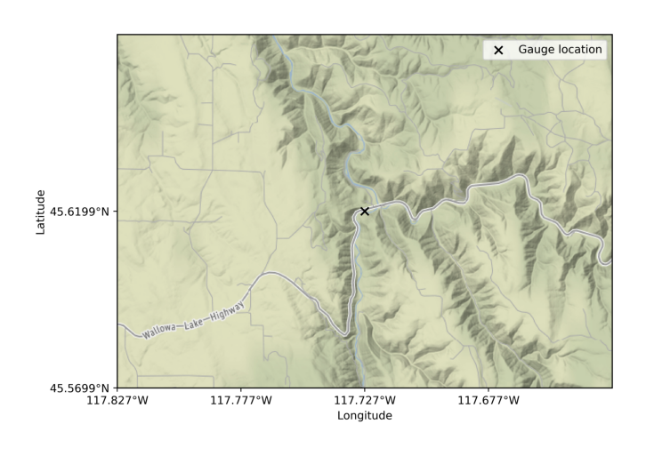

```python
%matplotlib inline
import matplotlib.pyplot as plt
import numpy as np
import pandas as pd
import camels

gauge_id = 13331500
camels.plot_basin(gauge_id)
```

The `camels` package provides a Python interface for the streamflow data. Using the `camels.pytorch.Streamflow` class you can access the time series data directly as `pytorch` tensors.

The available data spans the time range from 1980 to 2014. Of that, the first 26 years are used as training data, years 2006 to 2010 as validation data and years 2010 to 2014 as testing data.

```python
from camels.pytorch import Streamflow
training_data = Streamflow(gauge_id, "training")
validation_data = Streamflow(gauge_id, "validation")
testing_data = Streamflow(gauge_id, "testing")
```

The plot below gives an overview over a period of three years from the training data. The first three panels show the six meteorological forcings that are the inputs for modeling the streamflow:

- length of the day
- strength of incoming solar radiation
- precipitation
- (water) vapor pressure, i.e. the amount of water vapor in the air
- daily minimum temperature
- daily maximum temperature

The lowest panel shows the measured streamflow.

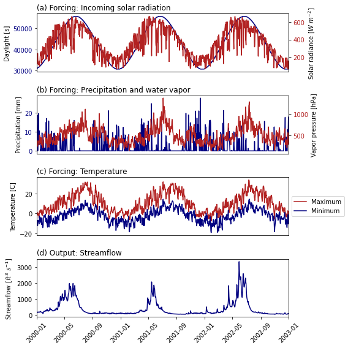

```python
from datetime import datetime
start = datetime(2000, 1, 1, hour=0)
end = datetime(2003, 1, 1, hour=0)
training_data.plot_overview(start, end)
```

## [Exercise 1] (1 point)

Describe any patterns you see in the time series of forcings and streamflow shown above. Provide a simple description of the physical processes that relate the forcings (input) to the streamflow (output).

$\underline{\textbf{Answer:}}$

The streamflow seems to be highest during May-June period according to the figure above. This is consistent throughout the 3 years-period. It is generally due to 3 major forcings (incoming solar radiation, precipitation and water vapor pressure and temperature). Having higher Solar radiance depends on the daylight that we have in a certain month. And having higher solar radiance will be proportional to high temperature.

In addition, the level of vapor pressure of the water is generally inversely proportional to the level of precipitation during certain month. On the other hand, the water vapor pressure is generally positively affecting the level of streamflow. However, during the time that there is no precipitation, the level of streamflow will decrease significantly as shown in every July.

Moreover, the temperature is generally positively affecting streamflow. However, at its peak, which coincides with the time when precipitation is at its lowest, the streamflow tends to be at its lowest.

### Training and testing data

The `Streamflow` dataset provides sequences of a length of 400 days of meteorological forcings and corresponding streamflows as samples. The `data_loader` member function can be used to instantiate `pytorch` dataloaders with a given batch size.

> **Note 1:** Input and outputs in the dataset are all normalized to have mean 0 and standard deviation 1. For simplicity, we will from now on consider forcings and outputs in normalized units instead of the units given in the plot above.

```python
training_loader = training_data.data_loader(batch_size=8)
validation_loader = validation_data.data_loader(batch_size=8)
```

## [Exercise 2] (2 points)

### 2, a) (1 point)

Write a custom `torch.nn.Module` subclass that implements the basic RNN from exercise 1 but including bias terms for the mappings from input to hidden state, hidden state to hidden state, and hidden state to output. This means that for step $t$, the hidden state $h_t$ and output $\hat{y}_t$ should be given by:

\begin{align} h_t &= \tanh( \mathbf{W}_{hx}\ x_t + \theta_{hx} + \mathbf{W}_{hh} \ h_{t - 1} + \theta_{hh}) \\ \hat{y}_t &= \mathbf{W}_{hy}\ h_t + \theta_y \end{align}

Make the size of the hidden state a parameter of the class constructor.

> **Hint 1:** You can use `torch.nn.Linear` layers to implement the linear mappings between input, hidden state, and output.

```python
import torch

class CustomRNN(torch.nn.Module):
    def __init__(self, input_size, hidden_size, output_size):
        super(CustomRNN, self).__init__()
        self.hidden_size = hidden_size
        self.input2hidden = torch.nn.Linear(input_size, hidden_size)
        self.hidden2output = torch.nn.Linear(hidden_size, output_size)

        self.softmax = torch.nn.LogSoftmax(dim=1)

    def forward(self, input, hidden):
        hidden = self.input2hidden(input)
        output = self.hidden2output(hidden)
        output = self.softmax(output)
        return output, hidden

    def init_hidden(self):
        return torch.zeros(1, self.hidden_size)
```

### 2, b) (1 point)

Train an instance of your RNN model class using mean squared error (MSE) loss on the streamflow training data. For the hidden state, a size around $64$ is a suitable first choice.

Monitor the validation loss by computing the MSE for a single predicted sequence of streamflows for the full validation time range. You can obtain the input and output tensors corresponding to the full validation range by calling the `get_range` member function of `validation_data`:

```
x,y = validation_data.get_range()
```

Plot training and validation losses.

> **Hint 1:** To train your RNN you are free to use all available `pytorch` functionality. Particularly the [`torch.optim`](https://pytorch.org/docs/stable/optim.html) module can be of interest.

> **Hint 2:** As baseline, training using the `Adam` optimizer with a learning rate of $10^{-2}$ for 40 epochs should give a significant reduction in training loss. The reduction in the validation will likely be much smaller.

```python
x,y = validation_data.get_range()
print(x)
print(y)
print((y.detach().numpy())[0].size)
```

```
tensor([[[-1.4096,  0.4236, -1.6163, -1.1057, -0.2429, -0.3023]],

        [[-1.4037,  0.2400, -1.3310, -0.8625, -0.2203, -0.2727]],

        [[-1.4012, -0.4181, -1.0396, -1.0113, -0.6676, -0.6795]],

        ...,

        [[-1.4388,  0.1533, -1.2284, -1.2576, -1.1051, -1.0148]],

        [[-1.4257,  1.0796, -1.6104, -1.3037, -0.6436, -0.6858]],

        [[-1.4134,  2.1957, -1.4892, -1.0753, -0.4963, -0.5477]]])
tensor([[[ 0.0799]],

        [[-0.0800]],

        [[-0.2226]],

        ...,

        [[-0.6643]],

        [[-0.6608]],

        [[-0.6574]]])
1
```

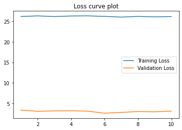

```python
#set device
cuda = torch.device("cuda")
cpu = torch.device("cpu")
if torch.cuda.is_available():
    device = cuda
else:
    device = cpu

# Plot function
def showPlot( num_epoches, hold_training_loss, hold_validation_loss):
  ecpoch=np.arange(1, num_epoches+1)

  plt.plot(ecpoch, hold_training_loss)
  plt.plot(ecpoch, hold_validation_loss)

  plt.title('Loss curve plot')
  plt.legend(['Training Loss', 'Validation Loss'])
  plt.show()

criterion=torch.nn.MSELoss()

N_INPUTS = 19200
N_HIDDENS = 64
N_OUTPUTS = 1
N_EPHOCS = 10

model1 = CustomRNN(N_INPUTS, N_HIDDENS, N_OUTPUTS)
optimizer = torch.optim.Adam(model1.parameters(), lr=0.01)

hold_training_loss=[]
hold_validation_loss=[]

for epoch in range(N_EPHOCS):  # loop over the dataset multiple times
    train_running_loss = 0.0
    model1.train()

    # TRAINING ROUND
    for i, data in enumerate(training_loader):
         # zero the parameter gradients
        optimizer.zero_grad()

        # init hidden states
        hidden =torch.zeros(1, 1, N_INPUTS)

        # get the inputs
        inputs, labels = data
        #print(len(inputs))
        inputs = inputs.view(-1, 1, N_INPUTS)

        # forward + backward + optimize
        outputs, hidden = model1(inputs, hidden)

        loss = criterion(outputs.view(-1), labels.view(-1))
        loss.backward()
        optimizer.step()

        train_running_loss += loss.detach().item()

    model1.eval()
    hold_training_loss.append(train_running_loss)

    val_running_loss = 0.0

    # VALIDATION ROUND
    for i, data in enumerate(validation_loader):
        # reset hidden states
        hidden =torch.zeros(1, 1, N_INPUTS)

        # get the inputs
        inputs, labels = data
        #print(len(inputs))
        inputs = inputs.view(-1, 1, N_INPUTS)

        # forward + backward + optimize
        outputs, hidden = model1(inputs, hidden)

        val_running_loss += loss.detach().item()
    hold_validation_loss.append(val_running_loss)


showPlot(N_EPHOCS, hold_training_loss, hold_validation_loss)
```

## [Exerise 3] (2 points)

### 3, a) (1 point)

Train a LSTM neural network on the streamflow data. The network should have at least one `LSTM` layer followed by fully-connected layer to map the hidden state to the output dimension.

> **Hint 1**: Use the `torch.nn.LSTM` class to implement the LSTM layer.

> **Hint 2:** Again, training using the `Adam` with a learning rate of $10^{-2}$ optimizer for 40 should give reasonable performance.

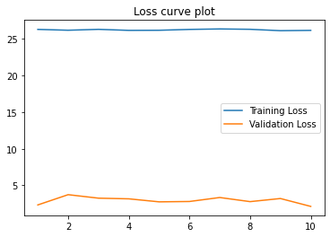

```python
#set device
cuda = torch.device("cuda")
cpu = torch.device("cpu")
if torch.cuda.is_available():
    device = cuda
else:
    device = cpu

import torch

class CustomLSTMmodel2(torch.nn.Module):
    def __init__(self, input_dim, hidden_dim, layer_dim, output_dim):
        super(CustomLSTMmodel2, self).__init__()
        self.hidden_dim = hidden_dim
        self.layer_dim = layer_dim

        #LSTM Layer
        self.lstm = torch.nn.LSTM(input_dim, hidden_dim, layer_dim, batch_first=True)

        # Linear Layer
        self.fc = torch.nn.Linear(hidden_dim, output_dim)


    def forward(self, x):
        # Initialize hidden state with zeros
        h0 = torch.zeros(self.layer_dim, x.size(0), self.hidden_dim).requires_grad_()

        # Initialize cell state
        c0 = torch.zeros(self.layer_dim, x.size(0), self.hidden_dim).requires_grad_()
        out, (hn, cn) = self.lstm(x, (h0.detach(), c0.detach()))

        # Index hidden state of last time step
        out = self.fc(out[:, -1, :])
        return out

BATCH_SIZE = 64
N_STEPS = 10
N_INPUTS = 6
N_NEURONS = 64
N_OUTPUTS = 10
N_EPHOCS = 10

model2 = CustomLSTMmodel2(N_INPUTS, N_NEURONS, N_STEPS, N_OUTPUTS)

optimizer = torch.optim.Adam(model2.parameters(), lr=0.01)
criterion=torch.nn.MSELoss()
hold_training_loss=[]
hold_validation_loss=[]

for epoch in range(N_EPHOCS):  # loop over the dataset multiple times
    train_running_loss = 0.0
    model2.train()

    # TRAINING ROUND
    for i, data in enumerate(training_loader):
         # zero the parameter gradients
        optimizer.zero_grad()

        # get the inputs
        inputs, labels = data
        #print(len(inputs))
        inputs = inputs.view(-1, 400,6)

        # forward + backward + optimize
        outputs = model2(inputs)

        loss = criterion(outputs, labels)
        loss.backward()
        optimizer.step()

        train_running_loss += loss.detach().item()

    model2.eval()
    hold_training_loss.append(train_running_loss)

    val_running_loss = 0.0
    # VALIDATION ROUND
    for i, data in enumerate(validation_loader):
        # get the inputs
        inputs, labels = data
        #print(len(inputs))
        inputs = inputs.view(-1, 400,6)

        # forward + backward + optimize
        outputs = model2(inputs)

        val_running_loss += loss.detach().item()
    hold_validation_loss.append(val_running_loss)

# Plot function
def showPlot( num_epoches, hold_training_loss, hold_validation_loss):
  ecpoch=np.arange(1, num_epoches+1)

  plt.plot(ecpoch, hold_training_loss)
  plt.plot(ecpoch, hold_validation_loss)

  plt.title('Loss curve plot')
  plt.legend(['Training Loss', 'Validation Loss'])
  plt.show()
showPlot(N_EPHOCS, hold_training_loss, hold_validation_loss)
```

### 3, b) (1 point)

Tune your model architecture and training routine to improve its performance. You should be able to achieve a validation loss of at least $0.45$. You could for example try a stacked LSTM or GRU cells.

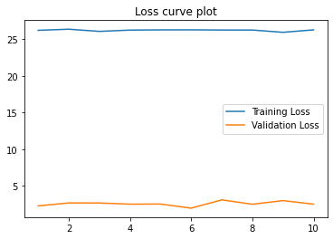

```python
#set device
cuda = torch.device("cuda")
cpu = torch.device("cpu")
if torch.cuda.is_available():
    device = cuda
else:
    device = cpu

import torch

class CustomLSTMmodel3(torch.nn.Module):
    def __init__(self, input_dim, hidden_dim, layer_dim, output_dim):
        super(CustomLSTMmodel3, self).__init__()
        self.hidden_dim = hidden_dim
        self.layer_dim = layer_dim

        #LSTM Layer
        self.lstm = torch.nn.LSTM(input_dim, hidden_dim, layer_dim, batch_first=True)

        # Linear Layer
        self.fc = torch.nn.Linear(hidden_dim, output_dim)


    def forward(self, x):
        # Initialize hidden state with zeros
        h0 = torch.zeros(self.layer_dim, x.size(0), self.hidden_dim).requires_grad_()

        # Initialize cell state
        c0 = torch.zeros(self.layer_dim, x.size(0), self.hidden_dim).requires_grad_()
        out, (hn, cn) = self.lstm(x, (h0.detach(), c0.detach()))

        # Index hidden state of last time step
        out = self.fc(out[:, -1, :])
        return out

#edit here
BATCH_SIZE = 64
N_STEPS = 28
N_INPUTS = 6
N_NEURONS = 64
N_OUTPUTS = 10
N_EPHOCS = 10

model3 = CustomLSTMmodel3(N_INPUTS, N_NEURONS, N_STEPS, N_OUTPUTS)

optimizer = torch.optim.Adam(model3.parameters(), lr=0.01)
criterion=torch.nn.MSELoss()
hold_training_loss=[]
hold_validation_loss=[]

for epoch in range(N_EPHOCS):  # loop over the dataset multiple times
    train_running_loss = 0.0
    model3.train()

    # TRAINING ROUND
    for i, data in enumerate(training_loader):
         # zero the parameter gradients
        optimizer.zero_grad()

        # get the inputs
        inputs, labels = data
        #print(len(inputs))
        inputs = inputs.view(-1, 400,6)

        # forward + backward + optimize
        outputs = model3(inputs)

        loss = criterion(outputs, labels)
        loss.backward()
        optimizer.step()

        train_running_loss += loss.detach().item()

    model3.eval()
    hold_training_loss.append(train_running_loss)

    val_running_loss = 0.0
    # VALIDATION ROUND
    for i, data in enumerate(validation_loader):
        # get the inputs
        inputs, labels = data
        #print(len(inputs))
        inputs = inputs.view(-1, 400,6)

        # forward + backward + optimize
        outputs = model3(inputs)

        val_running_loss += loss.detach().item()
    hold_validation_loss.append(val_running_loss)

# Plot function
def showPlot( num_epoches, hold_training_loss, hold_validation_loss):
  ecpoch=np.arange(1, num_epoches+1)

  plt.plot(ecpoch, hold_training_loss)
  plt.plot(ecpoch, hold_validation_loss)

  plt.title('Loss curve plot')
  plt.legend(['Training Loss', 'Validation Loss'])
  plt.show()
showPlot(N_EPHOCS, hold_training_loss, hold_validation_loss)
```

### [Exerise 4] (2 points)

> **Hint:** For plotting, you can use `test_data.data.index` to get the dates corresponding to the sequence returned by `test_data.get_range()`.

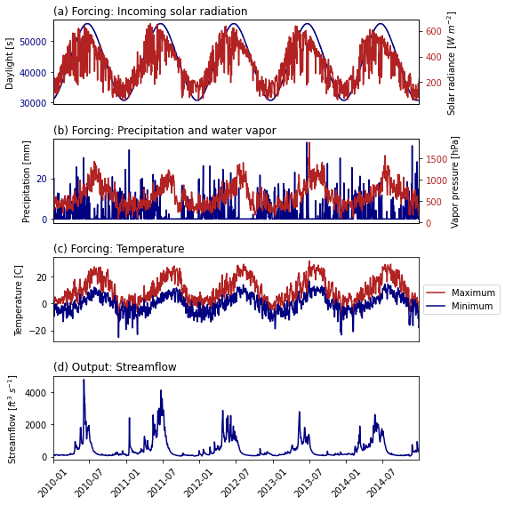

```python
testing_data = Streamflow(gauge_id, "testing")

testing_loader = testing_data.data_loader(batch_size=8)

start = testing_data.data.index[0]
end = testing_data.data.index[len(testing_data.data.index)-1]

testing_data = Streamflow(gauge_id, "testing")

testing_data.plot_overview(start, end)

for i, data in enumerate(testing_loader):
  inputs, labels = data
  inputs = inputs.view(-1, 3200, 6)
  output = labels
  outputs_model2 = model2(inputs)
  outputs_model3 = model3(inputs)
  hidden =torch.zeros(1, 1, 19200)
  inputs = inputs.view(-1, 1, 19200)
  outputs_model1, hidden = model1(inputs, hidden)
```

```python
import numpy as np

def getEvaluation(predicted, output):
  mae=abs(predicted.detach().numpy()-output.detach().numpy()).sum()/len(output)
  mse=((predicted.detach().numpy()-output.detach().numpy())*(predicted.detach().numpy()-output.detach().numpy())).sum()/len(output)
  return mae, mse


mae_model1, mse_model1= getEvaluation(outputs_model1, output);
mae_model2, mse_model2= getEvaluation(outputs_model2, output);
mae_model3, mse_model3= getEvaluation(outputs_model3, output);

print("MAE model 1: "+str(mae_model1))
print("MSE model 1: "+str(mse_model1))
print("MAE model 2: "+str(mae_model2))
print("MSE model 2: "+str(mse_model2))
print("MAE model 3: "+str(mae_model3))
print("MSE model 3: "+str(mse_model3))
```

```
MAE model 1: 6.3511181640625
MSE model 1: 11.072567138671875
MAE model 2: 63.27521484375
MSE model 2: 110.8680078125
MAE model 3: 63.518486328125
MSE model 3: 110.723603515625
```